# Assignment 8th September

1.Take car_crashes dataset from seaborn library

2.load the dataset

Accidents in the states of the USA are examined. This is the data set of the cause of the accidents and the cost to the accident insurance companies.

· total -> Number of drivers involved in fatal collisions per billion miles (5.900–23.900)

· speeding -> Percentage Of Drivers Involved In Fatal Collisions Who Were Speeding (1.792–9.450)

· alcohol -> Percentage Of Drivers Involved In Fatal Collisions Who Were Alcohol-Impaired (1.593–10.038)

· not_distracted -> Percentage Of Drivers Involved In Fatal Collisions Who Were Not Distracted (1.760–23.661)

· no_previous -> Percentage Of Drivers Involved In Fatal Collisions Who Had Not Been Involved In Any Previous Accidents (5.900–21.280)

· ins_premium -> Car Insurance Premiums (641.960–1301.520)

· ins_losses -> Losses incurred by insurance companies for collisions per insured driver (82.75–194.780)

· abbrev -> USA states

```python
import seaborn as sns
import pandas as pd
import matplotlib.pyplot as plt
```

```python
car_crashes = sns.load_dataset("car_crashes")
car_crashes.set_index("abbrev", inplace=True)
car_crashes.head()
```

| abbrev | total | speeding | alcohol | not_distracted | no_previous | ins_premium | ins_losses |
| --- | --- | --- | --- | --- | --- | --- | --- |
| AL | 18.8 | 7.332 | 5.640 | 18.048 | 15.040 | 784.55 | 145.08 |
| AK | 18.1 | 7.421 | 4.525 | 16.290 | 17.014 | 1053.48 | 133.93 |
| AZ | 18.6 | 6.510 | 5.208 | 15.624 | 17.856 | 899.47 | 110.35 |
| AR | 22.4 | 4.032 | 5.824 | 21.056 | 21.280 | 827.34 | 142.39 |
| CA | 12.0 | 4.200 | 3.360 | 10.920 | 10.680 | 878.41 | 165.63 |

```python
car_crashes.describe()
```

|  | total | speeding | alcohol | not_distracted | no_previous | ins_premium | ins_losses |
| --- | --- | --- | --- | --- | --- | --- | --- |
| count | 51.000000 | 51.000000 | 51.000000 | 51.000000 | 51.000000 | 51.000000 | 51.000000 |
| mean | 15.790196 | 4.998196 | 4.886784 | 13.573176 | 14.004882 | 886.957647 | 134.493137 |
| std | 4.122002 | 2.017747 | 1.729133 | 4.508977 | 3.764672 | 178.296285 | 24.835922 |
| min | 5.900000 | 1.792000 | 1.593000 | 1.760000 | 5.900000 | 641.960000 | 82.750000 |
| 25% | 12.750000 | 3.766500 | 3.894000 | 10.478000 | 11.348000 | 768.430000 | 114.645000 |
| 50% | 15.600000 | 4.608000 | 4.554000 | 13.857000 | 13.775000 | 858.970000 | 136.050000 |
| 75% | 18.500000 | 6.439000 | 5.604000 | 16.140000 | 16.755000 | 1007.945000 | 151.870000 |
| max | 23.900000 | 9.450000 | 10.038000 | 23.661000 | 21.280000 | 1301.520000 | 194.780000 |

3.Perfrom Data Visualization

4.Inference is must for each and every graph

```python
car_crashes.isna().all(axis= 0)
#checking for missing values (axis =1) to check the rows....can use all or any
```

```
total             False
speeding          False
alcohol           False
not_distracted    False
no_previous       False
ins_premium       False
ins_losses        False
dtype: bool
```

## Scatterplot to find a relations

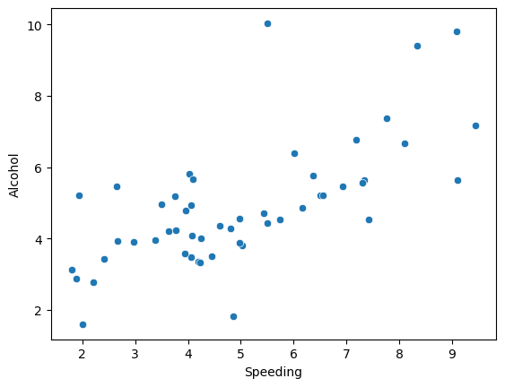

```python
sns.scatterplot(x="speeding", y="alcohol", data= car_crashes)
plt.xlabel('Speeding')
plt.ylabel('Alcohol')
```

This shows that there is a clear trend between speeding and alcohol. except for the few outliers, if we were to draw a best fit line, this would show a positive trend

According to this we can to some degree infer that speeding and alcohol are related, the drivers could be speeding due to intoxication

## Pie chart to vizualize why these collisions occur

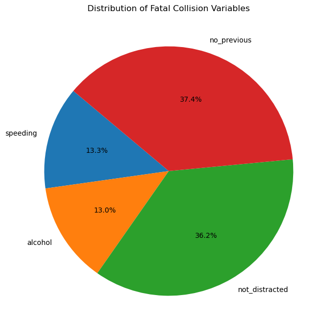

```python
variables = ["speeding", "alcohol", "not_distracted", "no_previous"]
mean_values = car_crashes[variables].mean()
plt.figure(figsize=(8, 8))
plt.pie(mean_values, labels=mean_values.index, autopct='%1.1f%%', startangle=140)
plt.title("Distribution of Fatal Collision Variables")
```

```python
corr = car_crashes.corr()
corr
```

|  | total | speeding | alcohol | not_distracted | no_previous | ins_premium | ins_losses |
| --- | --- | --- | --- | --- | --- | --- | --- |
| total | 1.000000 | 0.611548 | 0.852613 | 0.827560 | 0.956179 | -0.199702 | -0.036011 |
| speeding | 0.611548 | 1.000000 | 0.669719 | 0.588010 | 0.571976 | -0.077675 | -0.065928 |
| alcohol | 0.852613 | 0.669719 | 1.000000 | 0.732816 | 0.783520 | -0.170612 | -0.112547 |
| not_distracted | 0.827560 | 0.588010 | 0.732816 | 1.000000 | 0.747307 | -0.174856 | -0.075970 |
| no_previous | 0.956179 | 0.571976 | 0.783520 | 0.747307 | 1.000000 | -0.156895 | -0.006359 |
| ins_premium | -0.199702 | -0.077675 | -0.170612 | -0.174856 | -0.156895 | 1.000000 | 0.623116 |
| ins_losses | -0.036011 | -0.065928 | -0.112547 | -0.075970 | -0.006359 | 0.623116 | 1.000000 |

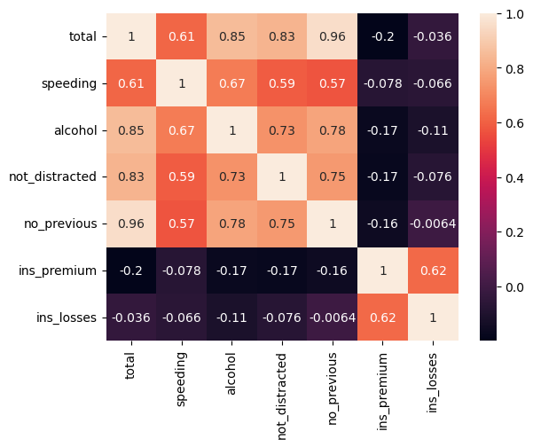

```python
sns.heatmap(corr, annot=True)
```

Inference:"Speeding" has a moderate positive correlation with "alcohol" (0.6697) and a weak positive correlation with "not_distracted" (0.5880). This suggests that states with higher percentages of speeding drivers also tend to have higher percentages of alcohol-impaired drivers and drivers who were not distracted. "Speeding" has a weak negative correlation with "ins_premium" (-0.0777) and "ins_losses" (-0.0659), indicating that states with higher percentages of speeding drivers tend to have slightly lower car insurance premiums and losses incurred by insurance companies.

"Ins_premium" and "ins_losses" both have weak negative correlations with most other variables. This suggests that states with higher car insurance premiums and losses incurred by insurance companies for collisions tend to have lower percentages of fatal collisions, lower percentages of alcohol-impaired drivers, lower percentages of speeding drivers, and lower percentages of drivers who were not distracted.